# Caret Preprocessing Examples

Adapted from https://topepo.github.io/caret/pre-processing.html

```r
library(caret)
library(ggplot2)
```

## Identifying Linear Dependencies between Predictors

Set up a 6 x 6 matrix where the first column is the sum of columns 2 and 3, and also of columns 4, 5 and 6

```r
ltfrDesign <- matrix(0, nrow=6, ncol=6)
ltfrDesign[,1] <- c(1, 1, 1, 1, 1, 1)
ltfrDesign[,2] <- c(1, 1, 1, 0, 0, 0)
ltfrDesign[,3] <- c(0, 0, 0, 1, 1, 1)
ltfrDesign[,4] <- c(1, 0, 0, 1, 0, 0)
ltfrDesign[,5] <- c(0, 1, 0, 0, 1, 0)
ltfrDesign[,6] <- c(0, 0, 1, 0, 0, 1)
ltfrDesign
```

```
     [,1] [,2] [,3] [,4] [,5] [,6]
[1,]    1    1    0    1    0    0
[2,]    1    1    0    0    1    0
[3,]    1    1    0    0    0    1
[4,]    1    0    1    1    0    0
[5,]    1    0    1    0    1    0
[6,]    1    0    1    0    0    1
```

Now find linear combinations of columns and indicate which columns can be removed. The function `findLinearCombos` uses the QR decomposition of a matrix to enumerate sets of linear combinations between predictors (columns)

```r
comboInfo <- findLinearCombos(ltfrDesign)
comboInfo
```

```
$linearCombos
$linearCombos[[1]]
[1] 3 1 2

$linearCombos[[2]]
[1] 6 1 4 5


$remove
[1] 3 6
```

```r
ltfrDesign[, -comboInfo$remove]
```

```
     [,1] [,2] [,3] [,4]
[1,]    1    1    1    0
[2,]    1    1    0    1
[3,]    1    1    0    0
[4,]    1    0    1    0
[5,]    1    0    0    1
[6,]    1    0    0    0
```

## Identifying Zero and Near-zero Variance Predictors

```r
data(mdrr)
```

Here’s a reasonably well-blanced structral descriptor (nR10, the number of 10-membered rings in the compound)

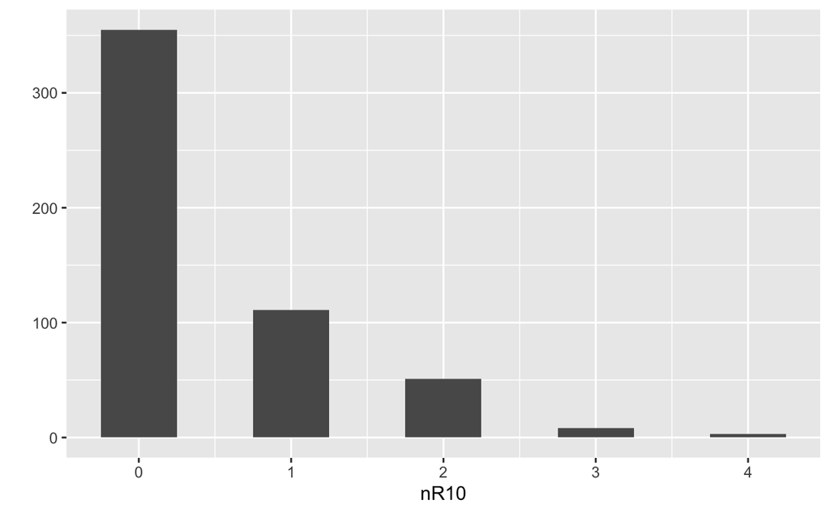

```r
library(ggplot2)
qplot(mdrrDescr$nR10,
      geom="histogram",
      bins = 5,
      binwidth = 0.5,
      xlab = "nR10")
```

One of the structural descriptors (nR11, the number of 11-membered rings) has only a few unique numerical values (0, 1, 2) that are highly unbalanced.

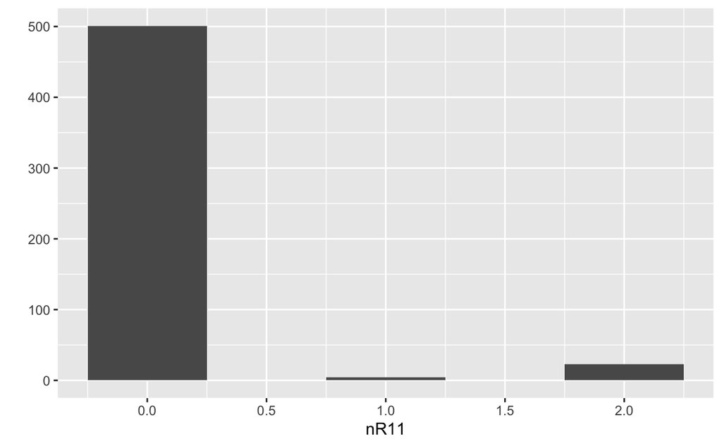

```r
qplot(mdrrDescr$nR11,
      geom="histogram",
      bins = 5,
      binwidth = 0.5,
      xlab = "nR11")
```

The concern here is that these predictors may become zero-variance predictors when the data are split into cross-validation/bootstrap sub-samples or that a few samples may have an undue influence on the model.

```r
nzv <- nearZeroVar(mdrrDescr, saveMetrics = TRUE)
nzv[40:50,]
```

|  | freqRatio | percentUnique | zeroVar | nzv |
| --- | --- | --- | --- | --- |
| nR10 | 3.198198 | 0.9469697 | FALSE | FALSE |
| nR11 | 21.782609 | 0.5681818 | FALSE | TRUE |
| nR12 | 57.666667 | 0.3787879 | FALSE | TRUE |
| nBnz | 2.377953 | 0.9469697 | FALSE | FALSE |
| ISIZ | 1.047619 | 13.6363636 | FALSE | FALSE |
| IAC | 1.250000 | 87.1212121 | FALSE | FALSE |
| AAC | 1.166667 | 58.5227273 | FALSE | FALSE |
| ZM1 | 1.052632 | 15.7196970 | FALSE | FALSE |
| ZM1V | 1.166667 | 60.0378788 | FALSE | FALSE |
| ZM2 | 1.222222 | 30.3030303 | FALSE | FALSE |

[output cut: 1 more lines]

```r
nzv_new <- nearZeroVar(mdrrDescr)
filteredDescr <- mdrrDescr[, -nzv_new]
dim(mdrrDescr)
```

```
[1] 528 342
```

```r
dim(filteredDescr)
```

```
[1] 528 297
```